# Rocket Launch Analysis-Bahasa

## **Sebuah Eksplorasi Data Peluncuran Roket: Tingkat Keberhasilan, Kegagalan, Tren Tahunan, dan Biaya Peluncuran**

**Pendahuluan:**

Di era teknologi dan eksplorasi ruang angkasa yang berkembang pesat ini, memahami dinamika peluncuran roket sangatlah penting. Dengan mendalami analisis data, kita dapat menggali informasi penting mengenai efisiensi, biaya, dan tingkat aktivitas berbagai organisasi dalam industri peluncuran roket.

Melalui aspek-aspek ini, kami bertujuan untuk memberikan pemahaman mendalam tentang dinamika industri peluncuran roket saat ini. Wawasan semacam itu sangat berharga bagi investor, peneliti, pembuat kebijakan, dan pemangku kepentingan lainnya.

### **Mengimpor Pustaka yang Akan Digunakan**

```python
import matplotlib.pyplot as plt
import pandas as pd
from mpl_toolkits.axes_grid1 import make_axes_locatable
import geopandas as gpd
import plotly.express as px
```

### **1. Memuat Data**

Pada bagian ini, kita menggunakan pustaka `pandas` untuk memuat dataset dari file CSV ke dalam DataFrame. Dataset ini berisi informasi tentang peluncuran roket. Setelah memuat, kita menampilkan lima baris pertama dari dataset untuk mendapatkan gambaran awal dari data tersebut.

```python
# Memuat data dari CSV ke DataFrame
data = pd.read_csv('C:/Users/User/Documents/Portofolio/Space+Missions+(start)/mission_launches.csv')

# Menampilkan 5 baris pertama dari data
data.head()
```

|  | Unnamed: 0.1 | Unnamed: 0 | Organisation | Location | Date | Detail | Rocket_Status | Price | Mission_Status |
| --- | --- | --- | --- | --- | --- | --- | --- | --- | --- |
| 0 | 0 | 0 | SpaceX | LC-39A, Kennedy Space Center, Florida, USA | Fri Aug 07, 2020 05:12 UTC | Falcon 9 Block 5 \| Starlink V1 L9 & BlackSky | StatusActive | 50.0 | Success |
| 1 | 1 | 1 | CASC | Site 9401 (SLS-2), Jiuquan Satellite Launch Ce... | Thu Aug 06, 2020 04:01 UTC | Long March 2D \| Gaofen-9 04 & Q-SAT | StatusActive | 29.75 | Success |
| 2 | 2 | 2 | SpaceX | Pad A, Boca Chica, Texas, USA | Tue Aug 04, 2020 23:57 UTC | Starship Prototype \| 150 Meter Hop | StatusActive | NaN | Success |
| 3 | 3 | 3 | Roscosmos | Site 200/39, Baikonur Cosmodrome, Kazakhstan | Thu Jul 30, 2020 21:25 UTC | Proton-M/Briz-M \| Ekspress-80 & Ekspress-103 | StatusActive | 65.0 | Success |
| 4 | 4 | 4 | ULA | SLC-41, Cape Canaveral AFS, Florida, USA | Thu Jul 30, 2020 11:50 UTC | Atlas V 541 \| Perseverance | StatusActive | 145.0 | Success |

### **2. Pra-pemrosesan Data**

Pada bagian ini, kami melakukan beberapa langkah untuk membersihkan data

- Menghapus kolom yang tidak diperlukan, yaitu kolom `unnamed: 0` dan `unnamed: 0.1`.
- Mengubah format kolom `Tanggal` menjadi tipe data `datetime` agar lebih mudah diproses pada langkah berikutnya.
- Menampilkan lima baris pertama dari data yang telah dibersihkan untuk memastikan perubahan telah diterapkan dengan benar.

```python
# Menghapus kolom yang tidak diperlukan
data.drop(['Unnamed: 0', 'Unnamed: 0.1'], axis=1, inplace=True)

# Mengubah kolom Date menjadi tipe data datetime
data['Date'] = pd.to_datetime(data['Date'])

# Menampilkan 5 baris pertama dari data yang telah dibersihkan
data.head()
```

|  | Organisation | Location | Date | Detail | Rocket_Status | Price | Mission_Status |
| --- | --- | --- | --- | --- | --- | --- | --- |
| 0 | SpaceX | LC-39A, Kennedy Space Center, Florida, USA | 2020-08-07 05:12:00+00:00 | Falcon 9 Block 5 \| Starlink V1 L9 & BlackSky | StatusActive | 50.0 | Success |
| 1 | CASC | Site 9401 (SLS-2), Jiuquan Satellite Launch Ce... | 2020-08-06 04:01:00+00:00 | Long March 2D \| Gaofen-9 04 & Q-SAT | StatusActive | 29.75 | Success |
| 2 | SpaceX | Pad A, Boca Chica, Texas, USA | 2020-08-04 23:57:00+00:00 | Starship Prototype \| 150 Meter Hop | StatusActive | NaN | Success |
| 3 | Roscosmos | Site 200/39, Baikonur Cosmodrome, Kazakhstan | 2020-07-30 21:25:00+00:00 | Proton-M/Briz-M \| Ekspress-80 & Ekspress-103 | StatusActive | 65.0 | Success |
| 4 | ULA | SLC-41, Cape Canaveral AFS, Florida, USA | 2020-07-30 11:50:00+00:00 | Atlas V 541 \| Perseverance | StatusActive | 145.0 | Success |

### **3. Perbandingan Jumlah Roket Aktif dengan Roket yang Sudah Tidak Beroperasi**

Menganalisis dan membandingkan jumlah roket yang masih aktif dengan roket yang sudah dipensiunkan atau tidak aktif lagi berdasarkan data yang tersedia.

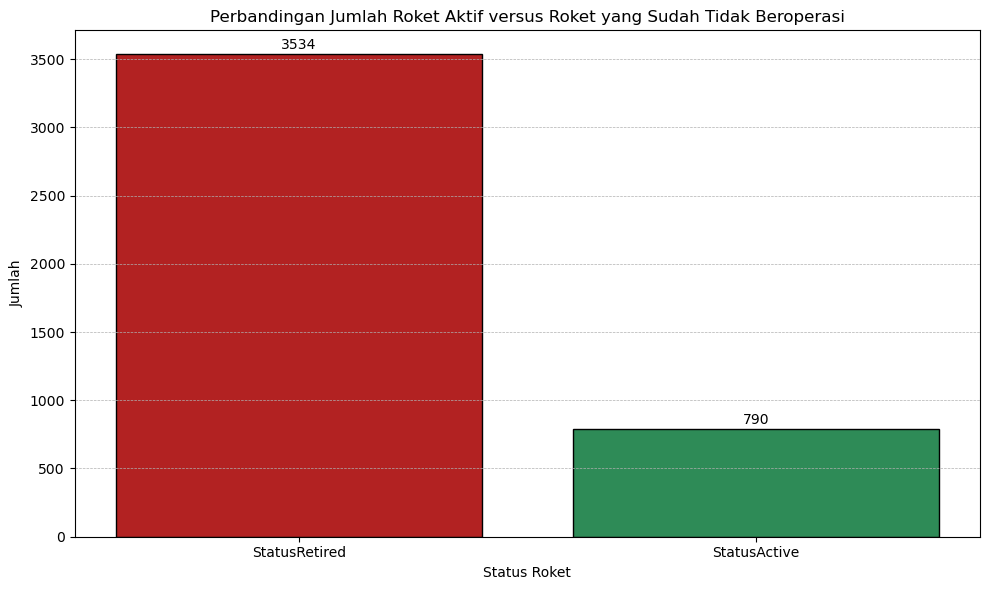

```
StatusRetired    3534
StatusActive      790
Name: Rocket_Status, dtype: int64
```

```python
# Menghitung jumlah roket yang aktif versus yang pensiun
rocket_status_counts = data['Rocket_Status'].value_counts()

# Membuat grafik batang untuk perbandingan roket aktif dan yang pensiun
plt.figure(figsize=(10, 6))
bars = plt.bar(rocket_status_counts.index, rocket_status_counts.values, color=['firebrick', 'seagreen'], edgecolor='black')

# Menambahkan nilai di atas setiap batang
for bar in bars:
    yval = bar.get_height()
    plt.text(bar.get_x() + bar.get_width()/2, yval + 15, int(yval), ha='center', va='bottom', fontsize=10)

plt.title('Perbandingan Jumlah Roket Aktif versus Roket yang Sudah Tidak Beroperasi')
plt.xlabel('Status Roket')
plt.ylabel('Jumlah')
plt.xticks(rotation=0)
plt.grid(axis='y', linestyle='--', linewidth=0.5)

plt.tight_layout()
plt.show()

rocket_status_counts
```

#### **Interpretasi Grafik**

- Mayoritas roket, 3.534, sudah tidak aktif atau dipensiunkan dan hanya 790 roket yang masih aktif.
- Sejumlah besar roket yang telah diluncurkan telah menyelesaikan misinya atau tidak lagi layak beroperasi.
- Roket yang masih aktif mungkin masih beroperasi atau siap untuk misi di masa depan. Roket yang lebih tua mungkin akan diganti dengan model yang lebih baru, lebih canggih dan efisien.
- Perubahan jumlah roket yang aktif dan yang dipensiunkan dapat mencerminkan evolusi teknologi roket dan kebijakan organisasi dari waktu ke waktu.

### **4. Analisis Status Peluncuran Roket**.

Pada bagian ini, kami menganalisis distribusi peluncuran roket berdasarkan status misinya. Dengan menggunakan fungsi `value_counts()`, kami menghitung jumlah peluncuran untuk setiap status misi dalam kumpulan data. Hasilnya akan menunjukkan berapa banyak misi yang berhasil, gagal, atau memiliki status lainnya.

```python
# Menghitung jumlah peluncuran berdasarkan status misinya
mission_status_counts = data['Mission_Status'].value_counts()

mission_status_counts
```

```
Success              3879
Failure               339
Partial Failure       102
Prelaunch Failure       4
Name: Mission_Status, dtype: int64
```

#### **Visualisasi Status Peluncuran**

Pada bagian ini, kita memvisualisasikan data yang telah dianalisis pada langkah sebelumnya. Dengan menggunakan pustaka `matplotlib`, kita membuat diagram batang untuk menampilkan jumlah peluncuran berdasarkan status misinya.

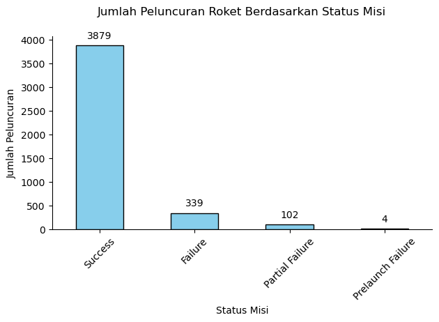

```python
# Menambahkan ruang di antara plot dan judul
ax = mission_status_counts.plot(kind='bar', color='skyblue', edgecolor='black')
ax.spines['top'].set_visible(False)
ax.spines['right'].set_visible(False)

plt.title("Jumlah Peluncuran Roket Berdasarkan Status Misi", y=1.08)  # Menyesuaikan posisi judul
plt.xlabel("Status Misi")
plt.ylabel("Jumlah Peluncuran")
plt.xticks(rotation=45)

# Menambahkan nilai asli di atas setiap batang
for p in ax.patches:
    ax.annotate(str(p.get_height()), (p.get_x() + p.get_width() / 2., p.get_height()),
                ha='center', va='center', xytext=(0, 10), textcoords='offset points')

plt.tight_layout()
plt.show()
```

Diagram batang di atas menunjukkan jumlah peluncuran roket berdasarkan status misinya. Berikut ini adalah interpretasi dari diagram batang di atas:

1. **Sukses:** Dengan 3879 peluncuran, ini adalah status yang paling umum. Hal ini menunjukkan bahwa sebagian besar misi peluncuran roket berhasil mencapai tujuannya tanpa masalah.
2. **Gagal:** Ada 339 misi yang gagal. Meskipun ini jauh lebih sedikit daripada jumlah misi yang berhasil, ini masih menunjukkan bahwa ada risiko yang terlibat dalam peluncuran roket.
3. **Kegagalan Sebagian:** Ada 102 misi yang mengalami kegagalan sebagian. Ini berarti bahwa misi tersebut mungkin telah mencapai sebagian dari tujuannya, tetapi tidak sesuai dengan yang diharapkan.
4. **Kegagalan Prapeluncuran:** Hanya ada 4 misi yang mengalami kegagalan sebelum peluncuran. Hal ini menunjukkan bahwa kejadian semacam ini sangat jarang terjadi, tetapi tetap penting untuk diwaspadai.

Kesimpulannya, meskipun sebagian besar misi peluncuran roket berhasil, namun masih ada sejumlah misi yang mengalami kegagalan, baik itu kegagalan total, kegagalan parsial, atau bahkan kegagalan pra-peluncuran. Hal ini mengingatkan kita akan kompleksitas dan tantangan yang ada dalam industri penerbangan antariksa.

### **5. Analisis Deret Waktu Jumlah Peluncuran Roket**

Dalam analisis ini, kami ingin mengetahui bagaimana tren peluncuran roket berubah dari waktu ke waktu, khususnya setiap tahun. Dengan mengelompokkan data berdasarkan tahun tanggal peluncuran, kita dapat menghitung berapa kali roket diluncurkan setiap tahunnya. kami menggunakan deret waktu untuk menampilkan tren jumlah peluncuran roket setiap tahunnya. Deret waktu memberikan gambaran yang jelas tentang bagaimana tren berubah dari tahun ke tahun.

#### **Peluncuran Roket per Tahun**

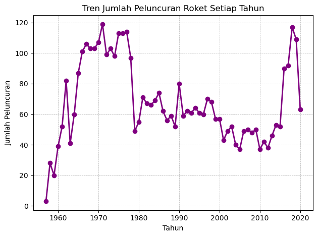

```python
# Menghilangkan informasi zona waktu dengan cara lain
data['Date'] = data['Date'].apply(lambda x: x.replace(tzinfo=None))

# Menghitung jumlah peluncuran roket setiap tahun
yearly_launches = data.groupby(data['Date'].dt.year)['Date'].count()

# Membuat line chart untuk tren jumlah peluncuran roket setiap tahun
yearly_launches.plot(kind='line', color='purple', marker='o', linewidth=2)
plt.title("Tren Jumlah Peluncuran Roket Setiap Tahun")
plt.xlabel("Tahun")
plt.ylabel("Jumlah Peluncuran")
plt.grid(True, which='both', linestyle='--', linewidth=0.5)
plt.tight_layout()
plt.show()
```

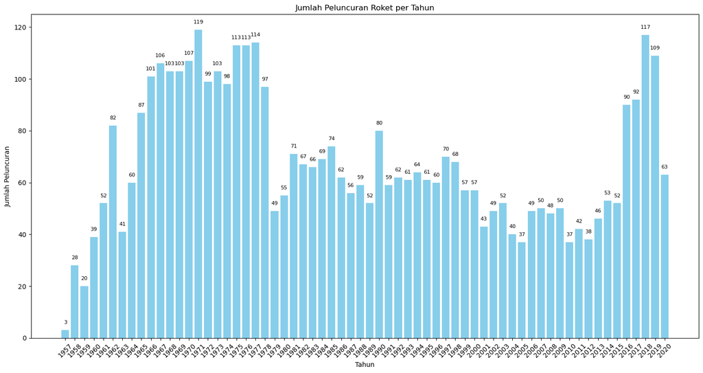

```python
# Mengambil informasi tahun dari kolom "Date" dengan pemrosesan string
data['Year'] = data['Date'].astype(str).str.split('-').str[0]

# Menghitung jumlah peluncuran per tahun
launches_per_year = data.groupby('Year').size()

launches_per_year


plt.figure(figsize=(15, 8))
bars = plt.bar(launches_per_year.index, launches_per_year.values, color='skyblue')

# Menambahkan nilai di atas setiap batang
for bar in bars:
    yval = bar.get_height()
    plt.text(bar.get_x() + bar.get_width()/2, yval + 2, int(yval), ha='center', va='bottom', fontsize=8)

plt.title('Jumlah Peluncuran Roket per Tahun')
plt.xlabel('Tahun')
plt.ylabel('Jumlah Peluncuran')
plt.xticks(rotation=45)
plt.tight_layout()

plt.show()
```

#### **Interpretasi Grafik**

- Secara keseluruhan, tampaknya ada peningkatan yang signifikan dalam jumlah peluncuran roket dari tahun 1960-an hingga sekitar pertengahan 1970-an, dan mencapai puncaknya pada pertengahan hingga akhir 1970-an.
- Setelah mencapai puncaknya pada akhir 1970-an, terjadi penurunan jumlah peluncuran roket yang terus berlanjut hingga sekitar awal 2000-an.
- Mulai dari pertengahan tahun 2000-an, tampaknya ada tren yang stabil dalam jumlah peluncuran roket setiap tahun dengan beberapa fluktuasi.
- Akhirnya, dalam beberapa tahun terakhir yang tersedia dalam kumpulan data, tampaknya ada peningkatan jumlah peluncuran roket. Namun, pada tahun-tahun di mana pandemi Covid-19 muncul, terjadi penurunan yang signifikan setelah peningkatan pada 2015-2018.

Dari grafik ini, kita dapat menyimpulkan bahwa ada periode-periode tertentu dalam sejarah peluncuran roket di mana aktivitasnya menjadi sangat intensif, diikuti dengan periode penurunan aktivitas. Faktor-faktor seperti perkembangan teknologi, kebijakan pemerintah, dinamika geopolitik, dan dampak pandemi mungkin berperan dalam mempengaruhi tren ini.

#### **Peluncuran Roket per Bulan**

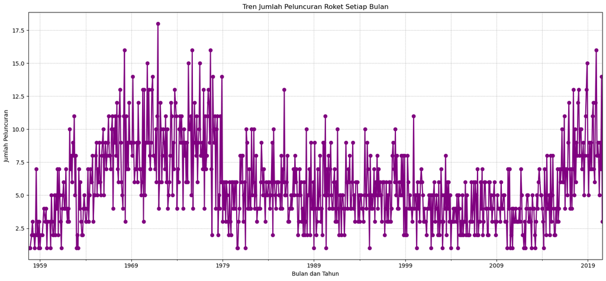

```python
# Menghapus informasi zona waktu dan mengkonversi kembali kolom "Date" ke tipe data datetime
data['Date'] = pd.to_datetime(data['Date'].astype(str).str.split('+').str[0])

# Menghitung jumlah peluncuran roket setiap bulan
monthly_launches = data.groupby(data['Date'].dt.to_period("M"))['Date'].count()

# Membuat line chart untuk tren jumlah peluncuran roket setiap bulan
plt.figure(figsize=(15, 7))
monthly_launches.plot(kind='line', color='purple', marker='o', linewidth=2)
plt.title("Tren Jumlah Peluncuran Roket Setiap Bulan")
plt.xlabel("Bulan dan Tahun")
plt.ylabel("Jumlah Peluncuran")
plt.grid(True, which='both', linestyle='--', linewidth=0.5)
plt.tight_layout()
plt.show()
```

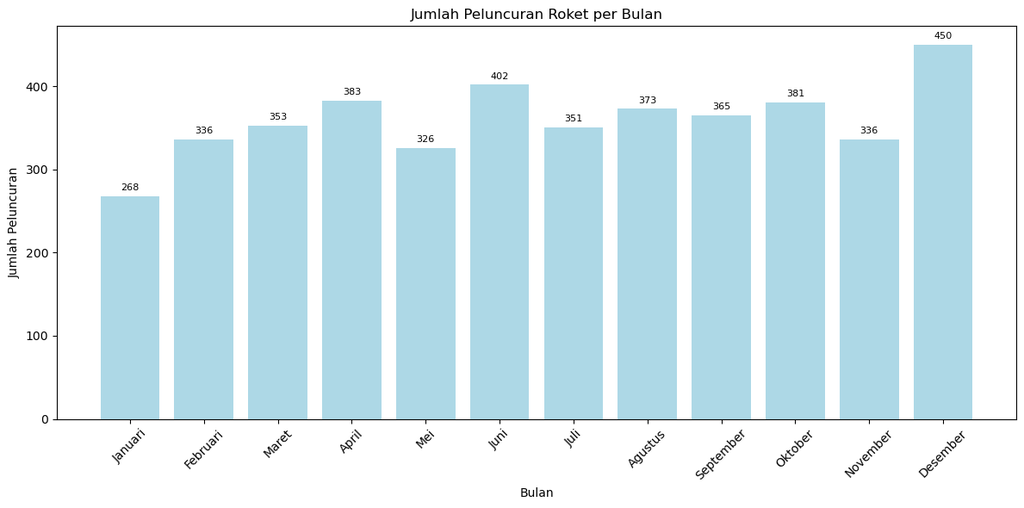

```python
# Mengekstrak informasi bulan dari string tanggal
data['Month'] = data['Date'].astype(str).str.split('-').str[1]

# Menghitung jumlah peluncuran untuk setiap bulan
launches_per_month_total = data.groupby('Month').size()

launches_per_month_total


# Membuat grafik batang untuk jumlah peluncuran per bulan
months = ["Januari", "Februari", "Maret", "April", "Mei", "Juni", "Juli", "Agustus", "September", "Oktober", "November", "Desember"]

plt.figure(figsize=(12, 6))
bars = plt.bar(months, launches_per_month_total.values, color='lightblue')

# Menambahkan nilai di atas setiap batang
for bar in bars:
    yval = bar.get_height()
    plt.text(bar.get_x() + bar.get_width()/2, yval + 5, int(yval), ha='center', va='bottom', fontsize=8)

plt.title('Jumlah Peluncuran Roket per Bulan')
plt.xlabel('Bulan')
plt.ylabel('Jumlah Peluncuran')
plt.xticks(rotation=45)
plt.tight_layout()

plt.show()
```

#### **Interpretasi Grafik**

- **Peluncuran Tertinggi di Bulan Desember**: Dengan 450 peluncuran, Desember menunjukkan aktivitas peluncuran roket tertinggi dibandingkan dengan bulan-bulan lainnya. Hal ini mungkin disebabkan oleh berbagai faktor, seperti kondisi cuaca, perencanaan misi, atau faktor lain yang mendukung peluncuran di bulan ini.
- **Aktivitas Tinggi di Pertengahan Tahun**: Juni hingga Oktober menunjukkan jumlah peluncuran yang relatif tinggi, yang mungkin mengindikasikan periode favorit untuk peluncuran roket.
- **Peluncuran Terendah di Bulan Januari**: Dengan 268 peluncuran, Januari memiliki aktivitas peluncuran roket terendah. Hal ini mungkin disebabkan oleh beberapa faktor seperti kondisi cuaca di awal tahun atau kurangnya perencanaan misi di bulan ini.
- **Distribusi Peluncuran**: Meskipun ada beberapa perbedaan antar bulan, tidak ada perbedaan ekstrem dalam distribusi peluncuran roket sepanjang tahun. Hal ini menunjukkan bahwa peluncuran roket terjadi dengan frekuensi yang relatif stabil sepanjang tahun.

Dari interpretasi di atas, kita dapat menyimpulkan bahwa meskipun ada beberapa variasi dalam jumlah peluncuran roket dari bulan ke bulan, peluncuran roket merupakan aktivitas sepanjang tahun dengan beberapa puncak dan lembah.

### **6. Analisis Jumlah Peluncuran Roket Berdasarkan Organisasi**.

Dalam analisis ini, kami menyelidiki organisasi mana yang paling aktif meluncurkan roket. Dengan menggunakan fungsi `value_counts()`, kami menghitung jumlah peluncuran untuk setiap organisasi yang tercantum dalam kumpulan data. Hasilnya menunjukkan organisasi dengan aktivitas peluncuran roket terbanyak.

```python
# Menghitung jumlah peluncuran roket berdasarkan organisasinya
organisation_counts = data['Organisation'].value_counts()

# Menampilkan 10 organisasi dengan jumlah peluncuran terbanyak
top_organisations = organisation_counts.head(10)

top_organisations
```

```
RVSN USSR           1777
Arianespace          279
CASC                 251
General Dynamics     251
NASA                 203
VKS RF               201
US Air Force         161
ULA                  140
Boeing               136
Martin Marietta      114
Name: Organisation, dtype: int64
```

#### **Visualisasi Jumlah Peluncuran Berdasarkan Organisasi**

Dalam visualisasi ini, kami memanfaatkan pustaka `matplotlib` untuk membuat grafik batang yang menampilkan 10 organisasi dengan jumlah peluncuran roket terbanyak. Grafik ini memberikan representasi visual dari dominasi beberapa organisasi dalam industri peluncuran roket.

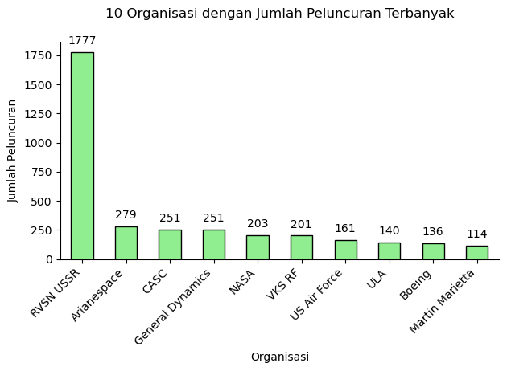

```python
# Membuat bar chart untuk 10 organisasi dengan jumlah peluncuran terbanyak
ax2 = top_organisations.plot(kind='bar', color='lightgreen', edgecolor='black')
ax2.spines['top'].set_visible(False)  # Menghilangkan garis atas
ax2.spines['right'].set_visible(False)  # Menghilangkan garis kanan

plt.title("10 Organisasi dengan Jumlah Peluncuran Terbanyak", y=1.08)  # Menambahkan ruang di antara plot dan judul
plt.xlabel("Organisasi")
plt.ylabel("Jumlah Peluncuran")
plt.xticks(rotation=45, ha='right')

# Menambahkan nilai asli di atas setiap batang
for p in ax2.patches:
    ax2.annotate(str(p.get_height()), (p.get_x() + p.get_width() / 2., p.get_height()),
                ha='center', va='center', xytext=(0, 10), textcoords='offset points')

plt.tight_layout()
plt.show()
```

**Interpretasi Grafik:**

- **RVSN USSR** adalah organisasi dengan jumlah peluncuran roket terbanyak, dengan lebih dari 1700 peluncuran. Hal ini menunjukkan dominasi organisasi ini dalam industri peluncuran roket, mungkin karena perannya yang penting selama periode tertentu dalam sejarah.
- **Arianespace** berada di urutan kedua, dengan lebih dari 250 peluncuran. Meskipun jauh di bawah RVSN USSR dalam hal jumlah, organisasi ini tetap merupakan organisasi penting dalam industri ini.
- **CASC** dan **General Dynamics** berada di posisi ketiga dan keempat dengan 251 peluncuran. Hal ini menunjukkan pertumbuhan dan keberadaan yang kuat dari organisasi-organisasi ini di dunia peluncuran roket.
- Organisasi lain seperti **VKS RF** dan **NASA** juga menunjukkan aktivitas yang signifikan dalam industri ini, dengan lebih dari 200 peluncuran.
- Ada perbedaan yang signifikan antara jumlah peluncuran roket **RVSN USSR** dan organisasi lain, menunjukkan dominasi kuat **RVSN USSR** selama periode operasionalnya.

Dari grafik ini, kita dapat menyimpulkan bahwa beberapa organisasi memiliki peran dominan dalam sejarah peluncuran roket, baik karena sejarah, teknologi, atau kebijakan tertentu yang mereka miliki.

### **7. Analisis Distribusi Harga Peluncuran Roket**

```python
# Analisis statistik deskriptif untuk kolom harga
price_description = data['Price'].describe()

price_description
```

```
count       964
unique       56
top       450.0
freq        136
Name: Price, dtype: object
```

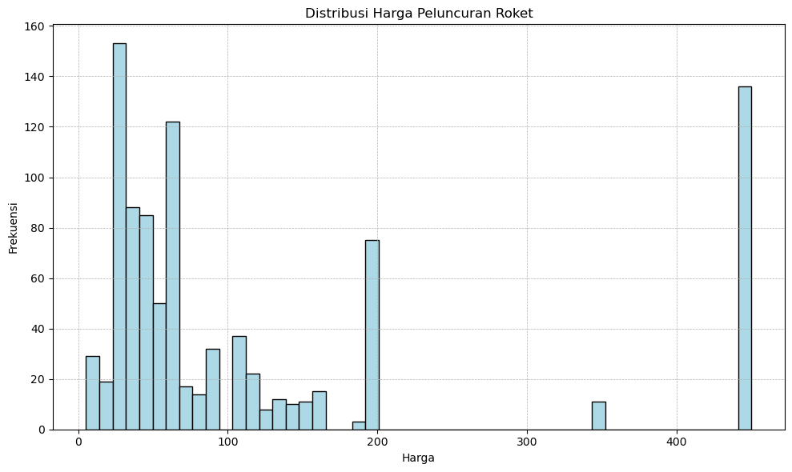

```python
# Mengonversi kolom 'Price' menjadi tipe data numerik
data['Price'] = pd.to_numeric(data['Price'], errors='coerce')

# Membuat histogram untuk distribusi harga
plt.figure(figsize=(10, 6))
plt.hist(data['Price'].dropna(), bins=50, color='lightblue', edgecolor='black')
plt.title("Distribusi Harga Peluncuran Roket")
plt.xlabel("Harga")
plt.ylabel("Frekuensi")
plt.grid(True, which='both', linestyle='--', linewidth=0.5)
plt.tight_layout()
plt.show()
```

Dengan demikian, kita dapat menyimpulkan bahwa meskipun ada beberapa peluncuran roket dengan biaya yang sangat tinggi, sebagian besar peluncuran roket memiliki biaya yang relatif lebih rendah hingga menengah.

### **8. Distribusi Aktivitas Jumlah Peluncuran Roket per Negara**

```python
# Ekstraksi negara dari kolom 'Location'
data['Country'] = data['Location'].str.split(', ').str[-1]

# Menghitung jumlah peluncuran untuk setiap negara
launches_per_country = data['Country'].value_counts().reset_index()
launches_per_country.columns = ['Country', 'Number_of_Launches']

launches_per_country.head()
```

|  | Country | Number_of_Launches |
| --- | --- | --- |
| 0 | Russia | 1395 |
| 1 | USA | 1344 |
| 2 | Kazakhstan | 701 |
| 3 | France | 303 |
| 4 | China | 268 |

```python
import plotly.graph_objects as go
fig = go.Figure(data=go.Choropleth(
    locations=launches_per_country['Country'],
    z=launches_per_country['Number_of_Launches'],
    locationmode='country names',
    colorscale="greens",
    autocolorscale=False,
    reversescale=False,
    marker_line_color='black',
    marker_line_width=0.5,
    colorbar_title='Number of Successful'
))

# Menyesuaikan latar belakang dan detail peta
fig.update_geos(
    showland=True,
    showcountries=True
)

fig.update_layout(
    title="Distribusi Aktivitas Keberhasilan Peluncuran Roket per Negara",
    geo=dict(
        showframe=False,
        showcoastlines=True
    )
)
# Menampilkan peta
fig.show()
```

[interactive chart not shown]

#### **Interpretasi Peta**

- Dari peta tersebut, kita dapat melihat bahwa beberapa negara memiliki warna yang lebih gelap, mengindikasikan bahwa mereka memiliki jumlah peluncuran roket yang tinggi. Hal ini dapat mencerminkan keberadaan institusi atau perusahaan penerbangan luar angkasa besar di negara tersebut atau adanya kebijakan pemerintah yang mendukung eksplorasi ruang angkasa.
- Sebaliknya, banyak negara dengan warna yang lebih terang menunjukkan lebih sedikit atau bahkan tidak ada aktivitas peluncuran roket. Hal ini dapat disebabkan oleh berbagai faktor, seperti keterbatasan teknologi, anggaran, atau prioritas nasional yang berbeda.
- Secara keseluruhan, peta ini memberikan gambaran umum tentang negara-negara terkemuka dalam industri peluncuran roket dan menunjukkan betapa beragamnya tingkat aktivitas di seluruh dunia.

Berikut adalah 10 negara dengan jumlah peluncuran roket terbanyak berdasarkan data yang tersedia:

- **Rusia** dengan 1.395 peluncuran.
- **Amerika Serikat** dengan 1.344 peluncuran
- **Kazakhstan** dengan 701 peluncuran.
- **Prancis** dengan 303 peluncuran.
- **Tiongkok** dengan 268 peluncuran.
- **Jepang** dengan 126 peluncuran.
- **India** dengan 76 peluncuran.
- **Iran** dengan 13 peluncuran.
- **Selandia Baru** juga dengan 13 peluncuran.
- **Israel** dengan 11 peluncuran.

```python
# Memfilter data untuk peluncuran yang gagal
failed_launches = data[data['Mission_Status'] == 'Failure']

# Menghitung jumlah peluncuran yang gagal untuk setiap negara
failed_launches_per_country = failed_launches['Country'].value_counts().reset_index()
failed_launches_per_country.columns = ['Country', 'Number_of_Failures']

failed_launches_per_country.head()
```

|  | Country | Number_of_Failures |
| --- | --- | --- |
| 0 | USA | 127 |
| 1 | Kazakhstan | 72 |
| 2 | Russia | 62 |
| 3 | China | 19 |
| 4 | France | 13 |

```python
import plotly.graph_objects as go
fig_failure = go.Figure(data=go.Choropleth(
    locations=failed_launches_per_country['Country'],
    z=failed_launches_per_country['Number_of_Failures'],
    locationmode='country names',
    colorscale="reds",
    autocolorscale=False,
    reversescale=False,
    marker_line_color='black',
    marker_line_width=0.5,
    colorbar_title='Number of Failures'
))

# Menyesuaikan latar belakang dan detail peta
fig_failure.update_geos(
    showland=True,
    showcountries=True
)

fig_failure.update_layout(
    title="Distribusi Aktivitas Kegagalan Peluncuran Roket per Negara",
    geo=dict(
        showframe=False,
        showcoastlines=True
    )
)
# Menampilkan peta
fig_failure.show()
```

[interactive chart not shown]

#### **Interpretasi Grafik**

Dari Peta Choropleth yang menunjukkan jumlah kegagalan peluncuran roket per negara, kita dapat melihat bahwa beberapa negara memiliki jumlah kegagalan yang lebih tinggi dibandingkan dengan negara lainnya. Hal ini mungkin disebabkan oleh berbagai faktor, termasuk jumlah total peluncuran, teknologi yang digunakan, dan kondisi peluncuran.

Daftar 10 Negara dengan Jumlah Kegagalan Peluncuran Roket Terbanyak:

- **Amerika Serikat** dengan 127 kegagalan.
- **Kazakhstan** dengan 72 kegagalan.
- **Rusia** dengan 62 kegagalan.
- **Cina** dengan 19 kegagalan.
- **Prancis** dengan 13 kegagalan.
- **Jepang** dengan 10 kegagalan.
- **India** dengan 8 kegagalan.
- **Iran** juga dengan 8 kegagalan.
- **Korea Utara** dengan 3 kegagalan.
- **Australia** juga dengan 3 kegagalan.

### **10. Persentase Kegagalan dan Keberhasilan Peluncuran Roket dari Waktu ke Waktu**

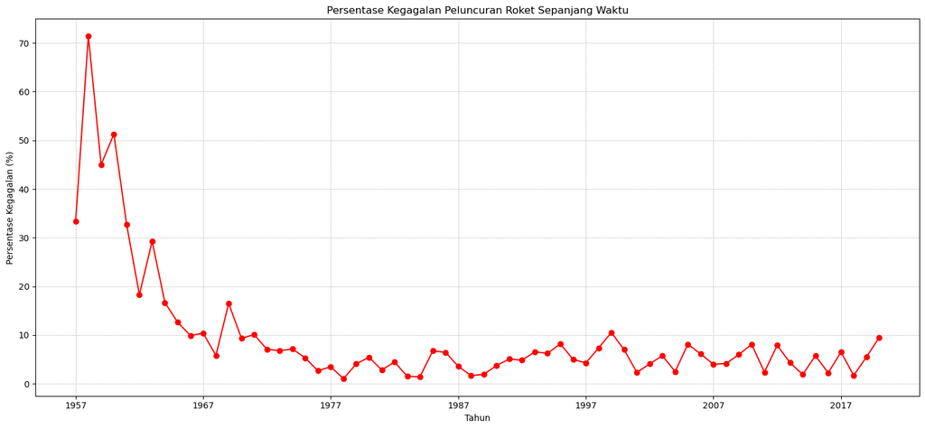

```python
# Menghitung total misi dan total kegagalan per tahun
total_missions_per_year = data.groupby('Year').size()
failures_per_year = data[data['Mission_Status'] == 'Failure'].groupby('Year').size()

# Menghitung persentase kegagalan
failure_percentage_per_year = (failures_per_year / total_missions_per_year) * 100

failure_percentage_per_year.head()

plt.figure(figsize=(15, 7))
failure_percentage_per_year.plot(linestyle='-', marker='o', color='red')

plt.title('Persentase Kegagalan Peluncuran Roket Sepanjang Waktu')
plt.xlabel('Tahun')
plt.ylabel('Persentase Kegagalan (%)')
plt.grid(True, which='both', linestyle='--', linewidth=0.5)
plt.tight_layout()

plt.show()
```

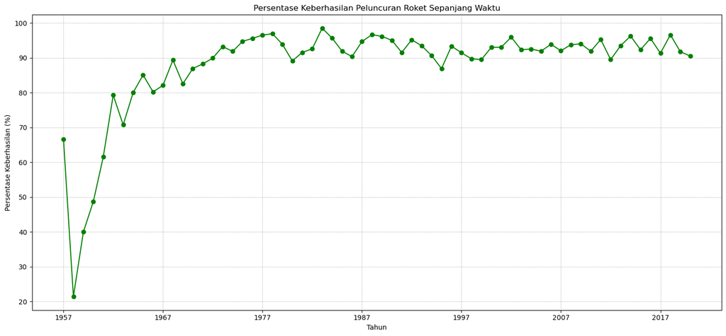

```python
# Menghitung total keberhasilan per tahun
successes_per_year = data[data['Mission_Status'] == 'Success'].groupby('Year').size()

# Menghitung persentase keberhasilan
success_percentage_per_year = (successes_per_year / total_missions_per_year) * 100

# Membuat grafik garis untuk persentase keberhasilan
plt.figure(figsize=(15, 7))
success_percentage_per_year.plot(linestyle='-', marker='o', color='green')

plt.title('Persentase Keberhasilan Peluncuran Roket Sepanjang Waktu')
plt.xlabel('Tahun')
plt.ylabel('Persentase Keberhasilan (%)')
plt.grid(True, which='both', linestyle='--', linewidth=0.5)
plt.tight_layout()

plt.show()
```

Dari interpretasi ini, kita dapat menyimpulkan bahwa negara-negara telah secara signifikan meningkatkan kemampuan mereka untuk meluncurkan roket dari waktu ke waktu, dengan peluang keberhasilan yang meningkat.